# Inference Of Population Means

Fairly Symmetric and unimodal.

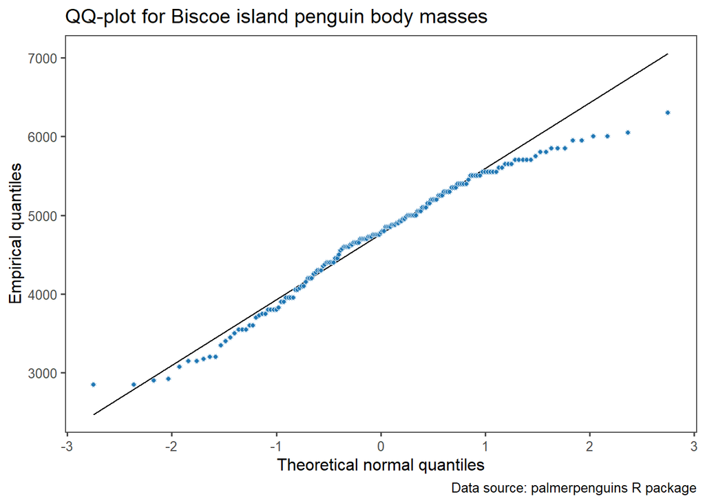

```r
# Creating a Quantile-Quantile (QQ) plot
penguins %>%
    dplyr::filter(island %in% c("Biscoe")) %>%
  ggplot(aes(sample = body_mass_g)) +
  stat_qq_line() +
  stat_qq(color = "white", fill = "#1F77B4", pch = 21) +
  labs(title = "QQ-plot for Biscoe island penguin body masses",
       x = "Theoretical normal quantiles",
       y = "Empirical quantiles",
       caption = "Data source: palmerpenguins R package")
```

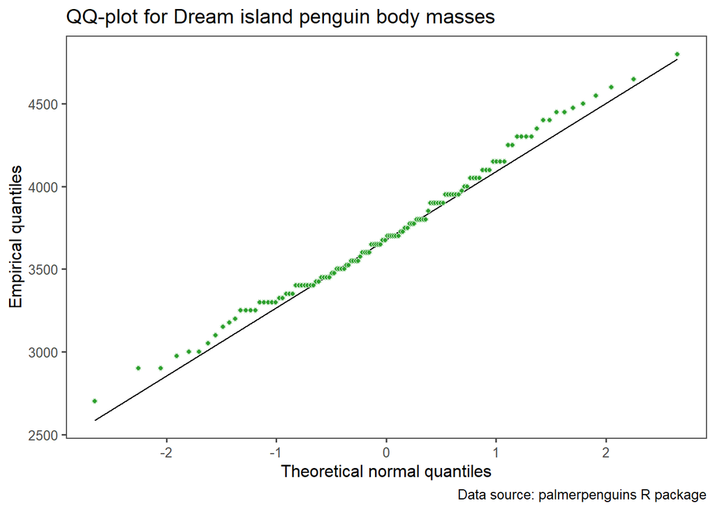

```r
# Creating a Quantile-Quantile (QQ) plot
penguins %>%
    dplyr::filter(island %in% c("Dream")) %>%
  ggplot(aes(sample = body_mass_g)) +
  stat_qq_line() +
  stat_qq(color = "white", fill = "#2CA02C", pch = 21) +
  labs(title = "QQ-plot for Dream island penguin body masses",
       x = "Theoretical normal quantiles",
       y = "Empirical quantiles",
       caption = "Data source: palmerpenguins R package")
```

### Provide our decision for the normality assumption for this data set, citing specific evidence from output obtained.

## Two-sample t-test

**Let’s conduct the unpooled independent samples t-test:**

```r
# Creating vectors of values
dreamMasses <- dplyr::filter(penguins, island == "Dream") %>%
  dplyr::pull(body_mass_g)

biscoeMasses <- dplyr::filter(penguins, island == "Biscoe") %>%
  dplyr::pull(body_mass_g)

# Implementing the two-sample t-test
ttestRes2 <- t.test(x = dreamMasses,
                    y = biscoeMasses,
                    mu = 0,
                    conf.level = 0.95)

# Printing model output
ttestRes2 %>%
  broom::tidy() %>%
  make_flex(ndigits = 1)
```

| estimate | estimate1 | estimate2 | statistic | p.value | parameter | conf.low | conf.high | method | alternative |
| --- | --- | --- | --- | --- | --- | --- | --- | --- | --- |
| -1,003.1 | 3,712.9 | 4,716.0 | -14.1 | <2e-16 | 264.8 | -1,143.3 | -862.9 | Welch Two Sample t-test | two.sided |

### Provide our test statistic, p-value, and decision at the 5% significance level citing evidence from the output.

**test statistic:** -14.1

**p-value:** <2e-16

**decision:** Since the p-value is <0.05, we reject the H<sub>0</sub>.

**Provide our interpretation of the result of the two-sample t-test based on our decision.**

Since the p-value is <0.05, we have sufficient evidence that the average body mass in grams for penguins from the Dream island is less that of penguins from Biscoe island at the 5% significance level.

*Any time we have a two sample t-test that is statistically significant (p-value < 0.05), we should indicate which group was higher or lower, on average in our interpretation.*

**Provide and interpret the confidence interval for the difference in the means between the two groups.**

**confidence interval:** (-1,143.3, -862.9) -> (862.9, 1143.3)

We are 95% confident that the mean body mass in grams for penguins from the Dream island is between 862.9 and 1143.3 grams less than that of penguins from the Biscoe island.

*We never include negative numbers / bounds in confidence interval interpretations.*

**Which is more useful for describing the difference, if any, between Dream island and Biscoe island penguins in terms of their average body masses - the two-sample t-test or the confidence interval? Why?**

The confidence interval was more useful since it tells us whether or not there is a statistically significant difference between the two groups, and it quantifies the magnitude of the difference between the two groups.